# Homework 01

## Introduction and first look at the data

## BDA - University of Tartu - Spring 2020

# 1. Python and Pandas (4.5 points)

- In this course we are going to use Python, and mainly Pandas data structures and data analysis tool. please make sure that you have went through the practise session carefully. After that please answer the following questions below about the abalone dataset.

First, let's import pandas package as pd and read data from the CSV file into a pandas DataFrame.

```python
# Remove future warning message
import warnings
warnings.simplefilter(action='ignore', category=FutureWarning)
```

```python
import pandas as pd
data = pd.read_csv("abalone.csv")
data
```

|  | Gender | Length | Diameter | Height | Weight | Rings |
| --- | --- | --- | --- | --- | --- | --- |
| 0 | F | 0.505 | 0.385 | 0.135 | 0.6185 | 12 |
| 1 | F | 0.650 | 0.475 | 0.165 | 1.3875 | 9 |
| 2 | I | 0.520 | 0.380 | 0.135 | 0.5395 | 8 |
| 3 | F | 0.550 | 0.425 | 0.140 | 0.9520 | 7 |
| 4 | M | 0.640 | 0.525 | 0.180 | 1.3135 | 10 |
| ... | ... | ... | ... | ... | ... | ... |
| 995 | I | 0.550 | 0.415 | 0.135 | 0.8095 | 12 |
| 996 | I | 0.455 | 0.435 | 0.110 | 0.4265 | 8 |
| 997 | M | 0.660 | 0.500 | 0.165 | 1.3195 | 9 |
| 998 | I | 0.525 | 0.400 | 0.130 | 0.6455 | 8 |
| 999 | M | 0.515 | 0.395 | 0.135 | 1.0070 | 8 |

1000 rows × 6 columns

`Question 0` is an example of how you should answer the following questions. First, in the `#TODO` cell you have to write the code representing your solution. And in the answer cell write the answer with your own words. It does not have to be a full sentence.

**1.0. What is overall memory consumption of the data?** (EXAMPLE)

```python
# TODO - here you have to write the code how did you find the answer.
data.memory_usage(deep=True).sum()
```

```
106128
```

**1.1. What are the column names of the dataset?** **(0.25 point)**

```python
# TODO
data.columns
```

```
Index(['Gender', 'Length', 'Diameter', 'Height', 'Weight', 'Rings'], dtype='object')
```

**Answer:** 'Gender', 'Length', 'Diameter', 'Height', 'Weight', 'Rings'

**1.2. How many observations (i.e. rows) are in this data frame?** **(0.25 point)**

```python
# TODO
data.index
```

```
RangeIndex(start=0, stop=1000, step=1)
```

**Answer:** 1000

**1.3. Print the first 5 lines from the dataset. What are the values of feature "Rings" of the printed observations?** **(0.25 point)**

```python
# TODO
data.head()
```

|  | Gender | Length | Diameter | Height | Weight | Rings |
| --- | --- | --- | --- | --- | --- | --- |
| 0 | F | 0.505 | 0.385 | 0.135 | 0.6185 | 12 |
| 1 | F | 0.650 | 0.475 | 0.165 | 1.3875 | 9 |
| 2 | I | 0.520 | 0.380 | 0.135 | 0.5395 | 8 |
| 3 | F | 0.550 | 0.425 | 0.140 | 0.9520 | 7 |
| 4 | M | 0.640 | 0.525 | 0.180 | 1.3135 | 10 |

**Answer:** 12, 9, 8, 7, 10

**1.4. Extract the last 3 rows of the data frame. What is the "Weight" of these abalones?** **(0.25 point)**

```python
# TODO
data['Weight'].tail(3)
```

```
997    1.3195
998    0.6455
999    1.0070
Name: Weight, dtype: float64
```

**Answer:** 1.3195, 0.6455, 1.0070

**1.5. What is the value of diameter in the row 577?** **(1 point)**

```python
# TODO
data.loc[576]['Diameter']
```

```
0.51
```

**Answer:** 0.51

**1.6. What is the mean of the height column?** **(0.5 point)**  
Hint 1: Use pandas describe() method

```python
# TODO
data['Height'].describe()
```

```
count    1000.000000
mean        0.141100
std         0.057064
min         0.000000
25%         0.115000
50%         0.145000
75%         0.165000
max         1.130000
Name: Height, dtype: float64
```

**Answer:** 0.141100

**1.7. Extract the subset of rows of the data frame where gender is M and weight values are below 0.75. What is the mean of diameter in this subset?** **(1 point)**

```python
# TODO
data[(data['Gender'] == "M") & (data['Weight'] < 0.75)].describe()
```

|  | Length | Diameter | Height | Weight | Rings |
| --- | --- | --- | --- | --- | --- |
| count | 119.000000 | 119.000000 | 119.000000 | 119.000000 | 119.000000 |
| mean | 0.444118 | 0.342647 | 0.115504 | 0.467366 | 8.865546 |
| std | 0.075819 | 0.063027 | 0.022193 | 0.196004 | 1.986925 |
| min | 0.235000 | 0.160000 | 0.055000 | 0.051500 | 4.000000 |
| 25% | 0.385000 | 0.295000 | 0.100000 | 0.291500 | 7.500000 |
| 50% | 0.465000 | 0.360000 | 0.115000 | 0.495500 | 9.000000 |
| 75% | 0.500000 | 0.385000 | 0.130000 | 0.643250 | 10.000000 |
| max | 0.575000 | 0.455000 | 0.190000 | 0.749500 | 14.000000 |

**Answer:** 0.342647

**1.8. What is the minimum of length when rings is equal to 18?** **(1 point)**

```python
# TODO
data[data['Rings'] == 18].describe()
```

|  | Length | Diameter | Height | Weight | Rings |
| --- | --- | --- | --- | --- | --- |
| count | 12.000000 | 12.000000 | 12.000000 | 12.000000 | 12.0 |
| mean | 0.570417 | 0.451250 | 0.172917 | 1.076625 | 18.0 |
| std | 0.074084 | 0.058742 | 0.028956 | 0.414502 | 0.0 |
| min | 0.465000 | 0.350000 | 0.120000 | 0.494000 | 18.0 |
| 25% | 0.523750 | 0.408750 | 0.162500 | 0.872125 | 18.0 |
| 50% | 0.557500 | 0.442500 | 0.177500 | 1.004750 | 18.0 |
| 75% | 0.608750 | 0.481250 | 0.195000 | 1.199500 | 18.0 |
| max | 0.725000 | 0.560000 | 0.210000 | 2.141000 | 18.0 |

**Answer:** 0.465000

# 2. Data understanding (2.5 point)

Collecting, describing, exploring and verifying data quality are **very important** steps in any data science task. In this exercise the main goal is to understand the attributes in the 'adult' dataset.

**2.0. Load data from the `adult.csv` file.**  
Hint 1: The extension of the filename may not always reflect the structure of data precisely. Are the values comma-separated (csv) or not?

```python
import numpy as np
import pandas as pd

# TODO
data = pd.read_table('adult.csv', index_col='X')
data
```

| X | age | workclass | education | occupation | capital.gain | capital.loss | native.country | salaries | jobsatisfaction | male | female |
| --- | --- | --- | --- | --- | --- | --- | --- | --- | --- | --- | --- |
| 0 | 39 | State-gov | Bachelors | Adm-clerical | 2174 | 0 | United-States | 43136.0 | 0 | 1.0 | NaN |
| 1 | 50 | Self-emp-not-inc | Bachelors | Exec-managerial | 0 | 0 | UnitedStates | 46209.0 | 7 | 1.0 | NaN |
| 2 | 38 | privat | HS-grad | Handlers-cleaners | 0 | 0 | United-States | 28937.0 | 6 | 1.0 | NaN |
| 3 | 53 | privat | 11th | Handlers-cleaners | 0 | 0 | United-States | 33658.0 | 6 | 1.0 | NaN |
| 4 | 28 | privat | Bachelors | Prof-specialty | 0 | 0 | Cuba | 34372.0 | 12 | NaN | 1.0 |
| ... | ... | ... | ... | ... | ... | ... | ... | ... | ... | ... | ... |
| 32556 | 27 | Private | Assoc-acdm | Tech-support | 0 | 0 | United-States | 21393.0 | 14 | NaN | 1.0 |
| 32557 | 40 | Private | HS-grad | Machine-op-inspct | 0 | 0 | United-States | 75199.0 | 10 | 1.0 | NaN |
| 32558 | 58 | Private | HS-grad | Adm-clerical | 0 | 0 | United-States | 25603.0 | 1 | NaN | 1.0 |
| 32559 | 22 | Private | HS-grad | Adm-clerical | 0 | 0 | United-States | 42138.0 | 3 | 1.0 | NaN |
| 32560 | 52 | Self-emp-inc | HS-grad | Exec-managerial | 15024 | 0 | United-States | 71709.0 | 9 | NaN | 1.0 |

32561 rows × 11 columns

**2.1. Name all the columns in this dataset and describe the meaning of each column with one sentence.**

```python
# TODO
data.columns
```

```
Index(['age', 'workclass', 'education', 'occupation', 'capital.gain',
       'capital.loss', 'native.country', 'salaries', 'jobsatisfaction', 'male',
       'female'],
      dtype='object')
```

**Answer:**

- age = the current age of the adult person
- workclass = the type of work including: private, self-emp-inc, state-gov
- education = the latest education level
- occupation = the name of the job
- capital.gain = a rise in the value of a capital asset (investment or real estate) that gives it a higher worth than the purchase price [(reference)](https://www.investopedia.com/terms/c/capitalgain.asp)
- capital.loss = the loss incurred when a capital asset, such as an investment or real estate, decreases in value [(reference)](https://www.investopedia.com/terms/c/capitalloss.asp)
- native.country = the country someone is born in or native to
- salaries = the annual salary of person in USD
- jobsatisfication = a measure of workers' contentedness with their job, whether or not they like the job or individual aspects or facets of jobs, such as nature of work or supervision. [(reference)](https://en.wikipedia.org/wiki/Job_satisfaction)
- male = describe the gender is male or not
- female = describe the gender is female or not

#### 2.1.1. In the following subtasks, you will have to visualise the distribution of the values for different features using appropriate diagrams. Visualisation is one of the easiest ways to get a good overview of the data and to notice any oddities, outliers etc.

```python
# Matplotlib is a Python 2D plotting library which produces publication quality figures in a variety of hardcopy formats
# and interactive environments across platforms. Matplotlib can be used in Python scripts, the Python and IPython shells,
# the Jupyter notebook, web application servers, and four graphical user interface toolkits.
import matplotlib.pyplot as plt

# allows to output plots in the notebook
%matplotlib inline

# Set the default style
plt.style.use("ggplot")
```

As an example, here is the age frequency histogram, where age is an attribute of type **numeric**:

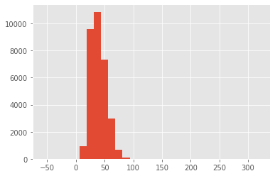

```python
# Columns may contain non-numeric values, errors or missing values. Therefore, non-numeric values must be dealt with.
if data is not ...:
    pd.to_numeric(data['age'], errors='coerce').hist(bins=30) # ‘coerce’ -> invalid parsing will be set as NaN
else:
    print('Please define `data` in earlier subtasks')
```

**2.2. Attribute `Workclass`. First, specify the type of the attribute (nominal / ordinal / numeric) and second, choose an appropriate chart type and visualise the distribution in the relative frequency scale.**

**Attribute type :** Nominal

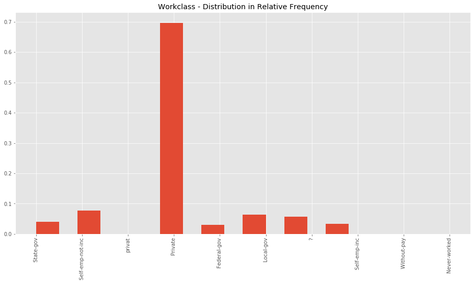

```python
# TODO
# data.workclass.value_counts().plot(kind="bar")
fig = plt.figure(figsize=[16, 8])

ax = plt.subplot(111)
ax.hist(data['workclass'],
         width = 0.5,
         weights = np.ones(len(data['workclass'])) / len(data['workclass'])
        )
ax.set_title('Workclass - Distribution in Relative Frequency')
plt.text
plt.xticks(rotation=90)
plt.show()
```

**2.3. Attribute `Education`. First, specify the type of the attribute (nominal / ordinal / numeric) and second, choose an appropriate chart type and visualise the distribution in the relative frequency scale.**

**Attribute type :** Ordinal

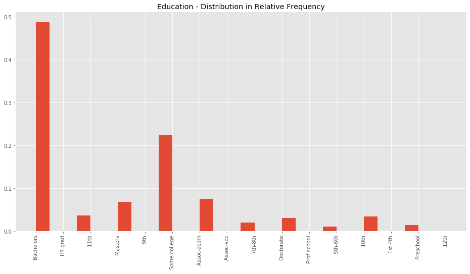

```python
# TODO
fig = plt.figure(figsize=[16, 8])

ax2 = plt.subplot(111)
ax2.hist(data['education'],
         width = 0.5,
         weights = np.ones(len(data['education'])) / len(data['education'])
        )
ax2.set_title('Education - Distribution in Relative Frequency')
plt.xticks(rotation=90)
plt.show()
```

**2.4. Attribute `Occupation`. First, specify the type of the attribute (nominal / ordinal / numeric) and second, choose an appropriate chart type and visualise the distribution in the relative frequency scale.**

**Attribute type :** Nominal

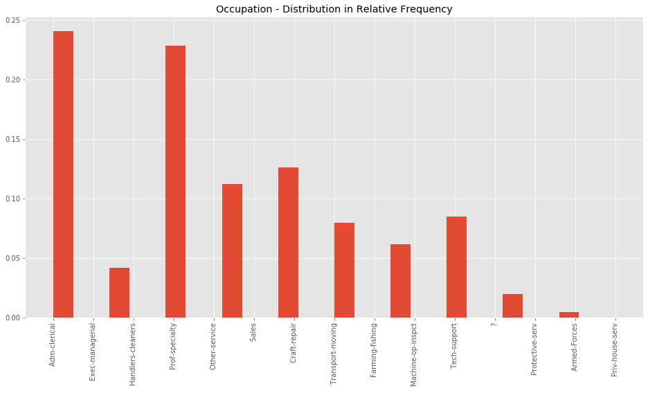

```python
# TODO
fig = plt.figure(figsize=[16, 8])

ax3 = plt.subplot(111)
ax3.hist(data['occupation'],
         width = 0.5,
         weights = np.ones(len(data['occupation'])) / len(data['occupation'])
        )
ax3.set_title('Occupation - Distribution in Relative Frequency')
plt.xticks(rotation=90)
plt.show()
```

**2.5. Attribute `Native Country`. First, specify the type of the attribute (nominal / ordinal / numeric) and second, choose an appropriate chart type and visualise the distribution in the relative frequency scale.**

**Attribute type :** Nominal

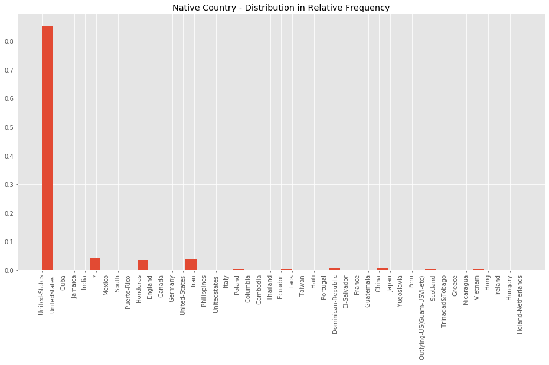

```python
# TODO
fig = plt.figure(figsize=[16, 8])

ax4 = plt.subplot(111)
ax4.hist(data['native.country'],
         width = 1,
         weights = np.ones(len(data['native.country'])) / len(data['native.country'])
        )
ax4.set_title('Native Country - Distribution in Relative Frequency')
plt.xticks(rotation=90)
plt.show()
```

**2.6. Attribute `Salaries`. First, specify the type of the attribute (nominal / ordinal / numeric) and second, choose an appropriate chart type and visualise the distribution in the density scale.**

**Attribute type :** numeric

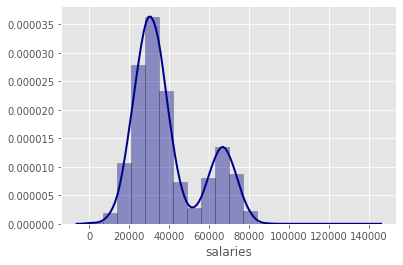

```python
# TODO
import seaborn as sns

sns.distplot(data['salaries'], hist=True, kde=True,
             bins=20, color = 'darkblue',
             hist_kws={'edgecolor':'black'},
             kde_kws={'linewidth': 2})
```

**2.7. Attributes `Male` and `Female`. First, specify the types of these attributes (nominal / ordinal / numeric) and second, choose an appropriate chart type and visualise the relative frequency of positive values in attribute `Male` and positive values in attribute `Female` (relative frequency of males and females).**

**Attribute type :** Nominal

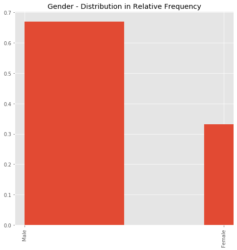

| X | age | workclass | education | occupation | capital.gain | capital.loss | native.country | salaries | jobsatisfaction | male | female | gender |
| --- | --- | --- | --- | --- | --- | --- | --- | --- | --- | --- | --- | --- |
| 0 | 39 | State-gov | Bachelors | Adm-clerical | 2174 | 0 | United-States | 43136.0 | 0 | 1.0 | NaN | Male |
| 1 | 50 | Self-emp-not-inc | Bachelors | Exec-managerial | 0 | 0 | UnitedStates | 46209.0 | 7 | 1.0 | NaN | Male |
| 2 | 38 | privat | HS-grad | Handlers-cleaners | 0 | 0 | United-States | 28937.0 | 6 | 1.0 | NaN | Male |
| 3 | 53 | privat | 11th | Handlers-cleaners | 0 | 0 | United-States | 33658.0 | 6 | 1.0 | NaN | Male |
| 4 | 28 | privat | Bachelors | Prof-specialty | 0 | 0 | Cuba | 34372.0 | 12 | NaN | 1.0 | Female |
| ... | ... | ... | ... | ... | ... | ... | ... | ... | ... | ... | ... | ... |
| 32556 | 27 | Private | Assoc-acdm | Tech-support | 0 | 0 | United-States | 21393.0 | 14 | NaN | 1.0 | Female |
| 32557 | 40 | Private | HS-grad | Machine-op-inspct | 0 | 0 | United-States | 75199.0 | 10 | 1.0 | NaN | Male |
| 32558 | 58 | Private | HS-grad | Adm-clerical | 0 | 0 | United-States | 25603.0 | 1 | NaN | 1.0 | Female |
| 32559 | 22 | Private | HS-grad | Adm-clerical | 0 | 0 | United-States | 42138.0 | 3 | 1.0 | NaN | Male |
| 32560 | 52 | Self-emp-inc | HS-grad | Exec-managerial | 15024 | 0 | United-States | 71709.0 | 9 | NaN | 1.0 | Female |

32561 rows × 12 columns

```python
# TODO - Put Male and Female attributes on the same plot for comparison
data['gender'] = data['male'].apply(lambda x: 'Male' if x == 1.0 else 'Female')

# TODO
fig = plt.figure(figsize=[8, 8])

ax4 = plt.subplot(111)
ax4.hist(data['gender'],
         width = 0.5,
         weights = np.ones(len(data['gender'])) / len(data['gender'])
        )
ax4.set_title('Gender - Distribution in Relative Frequency')
plt.xticks(rotation=90)
plt.show()
data
```

**2.8. Count the number of missing values in each attribute in the dataset and also report the percentage of missing values out of all rows (the original file uses '?' for missing values)**

```python
#TODO
total_rows = len(data.index)
total_missing = 0
if data is not data.empty:
    for column in data.columns:
        total_missing = len(data[data[column] == '?'])
        if total_missing > 0:
            print (f"Percentage of missing values in attribute {column} = {round((total_missing/total_rows)*100,2)}%")
else:
    print('Please define `data` in earlier subtasks')
```

```
Percentage of missing values in attribute age = 0.3%
Percentage of missing values in attribute workclass = 5.64%
Percentage of missing values in attribute occupation = 5.66%
Percentage of missing values in attribute native.country = 1.79%
```

# 3. Data preparation (1.5 points)

Preparing the data for analysis is the most crucial phase in data analysis. In this exercise, the main goal is to clean up the dataset 'adult'. The dataset has been made unclean on purpose so that you can practice cleaning it up. Most of the introduced uncleanliness is of the same kinds as described in slides of Lecture 02. Additionally, some values have been introduced which are non-sensical due to the meaning of the attribute.

First, let's make a deep copy of the original DataFrame. Later we will compare it to the cleaned/modified DataFrame.

```python
if data is not data.empty:
    original_data = data.copy(deep=True) # Make a deep copy, including a copy of the data and the indices
```

**3.1. Sometimes values include leading and/or trailing spaces. Remove leading and trailing whitespace from strings. Count how many rows were changed in the dataset.**

```python
# TODO
for column in data.columns:
    if data[column].dtype == 'O' : #dtype == 'O' stands for Python object, to check if data type is string or not
        data[column] = data[column].str.strip()
    else:
        print(f"column {column} is not string")
```

```
column capital.gain is not string
column capital.loss is not string
column salaries is not string
column male is not string
column female is not string
```

Use code below to count how many rows were affected.

```python
# Count differences
if data is not data.empty:
    data_all = pd.concat([original_data, data]).drop_duplicates()
    diff = data_all.shape[0] - data.shape[0]
    print ('Difference: ' + str(diff))
```

```
Difference: 32561
```

**Answer:** 32561

**3.2. Replace all non-sensical values in `data` with np.nan from numpy package to denote missing values (Original file uses '?' for missing values). Fix the typos in the dataset. Justify all the changes that you do, explaining why you are sure that this is a correct change and what you think the cause for such error could be.**

```python
# TODO
data_clean = data.replace(['?','privat','UnitedStates', 'Unitedstates', 'Hong'], [np.nan,'Private','United-States', 'United-States', 'Hong-Kong'])
data_clean.head(10)
```

| X | age | workclass | education | occupation | capital.gain | capital.loss | native.country | salaries | jobsatisfaction | male | female | gender |
| --- | --- | --- | --- | --- | --- | --- | --- | --- | --- | --- | --- | --- |
| 0 | 39 | State-gov | Bachelors | Adm-clerical | 2174 | 0 | United-States | 43136.0 | 0 | 1.0 | NaN | Male |
| 1 | 50 | Self-emp-not-inc | Bachelors | Exec-managerial | 0 | 0 | United-States | 46209.0 | 7 | 1.0 | NaN | Male |
| 2 | 38 | Private | HS-grad | Handlers-cleaners | 0 | 0 | United-States | 28937.0 | 6 | 1.0 | NaN | Male |
| 3 | 53 | Private | 11th | Handlers-cleaners | 0 | 0 | United-States | 33658.0 | 6 | 1.0 | NaN | Male |
| 4 | 28 | Private | Bachelors | Prof-specialty | 0 | 0 | Cuba | 34372.0 | 12 | NaN | 1.0 | Female |
| 5 | 37 | Private | Masters | Exec-managerial | 0 | 0 | United-States | 15745.0 | 4 | NaN | 1.0 | Female |
| 6 | 49 | Private | 9th | Other-service | 0 | 0 | Jamaica | 25117.0 | 7 | NaN | 1.0 | Female |
| 7 | 52 | Self-emp-not-inc | HS-grad | Exec-managerial | 0 | 0 | United-States | 75984.0 | 5 | 1.0 | NaN | Male |
| 8 | 31 | Private | Masters | Prof-specialty | 14084 | 0 | United-States | 68495.0 | 12 | NaN | 1.0 | Female |
| 9 | 42 | Private | Bachelors | Exec-managerial | 5178 | 0 | United-States | 60754.0 | 5 | 1.0 | NaN | Male |

**Answer:** Beside replace `?` with `NaN` value, we also replace this string `['privat','UnitedStates', 'Unitedstates', 'Hong']` into `['Private','United-States', 'United-States', 'Hong-Kong']` to fix the typo and reduce the redudancy of the same value (for example: United-States and UnitedStates is the same value in `native.country`.

**3.3. Count the rows which were changed in the subtask b**

```python
# TODO
if data_clean is not data_clean.empty:
    data_all = pd.concat([data, data_clean]).drop_duplicates()
    diff = data_all.shape[0] - data_clean.shape[0]
    print ('Difference: ' + str(diff))
```

```
Difference: 4186
```

**Answer:** 4186

**3.4. Report values that look suspicious whereas you are not sure whether they are definitely wrong**

**Answer:**

- value `Hong` in column `native.country`, we're not sure is it truly the name of the country `Hong Kong` or another meaning
- value in `capital.gain` and `capital.loss` which are containing too many `0` value
- value `Assoc-acdm` in `education` column

# 4. Gathering interesting facts about the adult dataset (1.5 points)

Useful information about the data can be acquired through visualization even before modeling.

**4.1. Convert the attribute `Education` into type `category` and introduce the order for this attribute based on the educational level (e.g. Masters is higher education than Bachelors; use your best guess in ordering those levels for which the order is not obvious). Create a bar chart visualising the relative frequencies of values.**

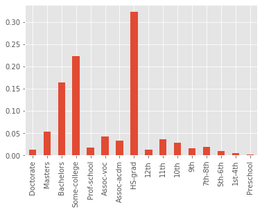

```python
# TODO
data['education'] = data['education'].astype('category')

data['education'].value_counts(normalize = True).reindex(['Doctorate', 'Masters',
                                          'Bachelors', 'Some-college', 'Prof-school', 'Assoc-voc', 'Assoc-acdm',
                                          'HS-grad', '12th',
                                          '11th', '10th',
                                          '9th', '7th-8th',
                                          '5th-6th', '1st-4th',
                                          'Preschool'
                                         ]).plot(kind="bar")
```

**4.2. Create and print a Pandas data frame where each row stands for an occupation, each column stands for a level of education, and the cells in the table contain the average salary of people with the corresponding occupation and education level.**  
Hint 1: You can use crosstab, see also aggfunc from the pandas documentation.

```python
# TODO
crosstab_df = pd.crosstab(data.occupation, data.education, values = data.salaries, aggfunc=np.mean).round(2)
crosstab_df
```

| education occupation | 10th | 11th | 12th | 1st-4th | 5th-6th | 7th-8th | 9th | Assoc-acdm | Assoc-voc | Bachelors | Doctorate | HS-grad | Masters | Preschool | Prof-school | Some-college |
| --- | --- | --- | --- | --- | --- | --- | --- | --- | --- | --- | --- | --- | --- | --- | --- | --- |
| ? | 31292.25 | 29582.05 | 31123.75 | 30193.58 | 31864.57 | 32282.27 | 31683.63 | 34653.87 | 36020.44 | 40028.50 | 57649.47 | 33286.82 | 43630.42 | 24989.20 | 46083.56 | 32974.99 |
| Adm-clerical | 29957.97 | 29976.85 | 29722.61 | NaN | 26075.00 | 35226.91 | 32473.00 | 34836.39 | 33989.10 | 38987.47 | 43041.60 | 34729.64 | 42550.85 | 31927.50 | 44568.11 | 34387.94 |
| Armed-Forces | NaN | NaN | 48635.00 | NaN | NaN | NaN | NaN | NaN | NaN | 15014.00 | NaN | 35544.00 | 67993.00 | NaN | NaN | 19421.00 |
| Craft-repair | 35271.21 | 36050.30 | 35800.19 | 32884.09 | 33559.63 | 33048.06 | 35322.85 | 41023.08 | 42391.51 | 45141.61 | 54458.50 | 38615.12 | 46957.59 | 33937.50 | 52143.71 | 41353.64 |
| Exec-managerial | 38655.33 | 36805.44 | 36365.31 | 50014.50 | 71742.00 | 42949.74 | 38819.62 | 46605.03 | 45784.69 | 50908.82 | 63967.98 | 42182.16 | 57455.88 | NaN | 58638.12 | 43447.34 |
| Farming-fishing | 32535.09 | 34774.05 | 33999.88 | 31450.00 | 30814.36 | 33664.48 | 31886.18 | 32939.19 | 38431.48 | 39866.14 | 70039.00 | 35043.57 | 40793.10 | 32559.33 | 43915.50 | 33912.57 |
| Handlers-cleaners | 32047.00 | 30906.23 | 32224.45 | 31633.06 | 32748.48 | 30780.35 | 34131.20 | 33321.33 | 34322.86 | 37371.94 | NaN | 32552.26 | 29983.00 | 30799.00 | NaN | 32719.36 |
| Machine-op-inspct | 32183.33 | 31165.66 | 28159.49 | 32227.96 | 33421.93 | 33776.59 | 32178.88 | 43272.30 | 39073.59 | 38791.84 | 70502.00 | 35660.08 | 31144.50 | 32628.82 | 38026.00 | 36279.22 |
| Other-service | 30484.64 | 31202.76 | 31881.76 | 29770.65 | 31433.08 | 31001.63 | 31044.70 | 33145.14 | 33618.78 | 35861.41 | 71626.00 | 32137.30 | 32017.68 | 32498.47 | 37343.75 | 31471.02 |
| Priv-house-serv | 33172.00 | 27458.43 | 34069.25 | 25066.36 | 26133.07 | 28921.25 | 33230.20 | 16753.50 | 34781.25 | 37750.43 | NaN | 31240.14 | 28568.00 | 26577.00 | NaN | 31587.56 |
| Prof-specialty | 45071.67 | 30745.05 | 37524.00 | 23128.50 | 39091.00 | 28300.22 | 35095.00 | 40030.98 | 42809.15 | 44600.97 | 56764.62 | 40999.92 | 48030.88 | 34861.00 | 58333.60 | 40584.20 |
| Protective-serv | 26930.17 | 38363.14 | 30582.83 | 41685.00 | 19378.00 | 30010.33 | 33974.00 | 42760.50 | 41284.54 | 50673.92 | NaN | 39481.47 | 48472.13 | NaN | 64038.00 | 43383.00 |
| Sales | 33370.27 | 31411.95 | 35273.38 | 31324.25 | 39858.67 | 37247.90 | 33974.47 | 40032.57 | 38573.94 | 47796.29 | 53759.50 | 37536.60 | 52718.71 | NaN | 52483.89 | 38450.69 |
| Tech-support | 44464.67 | 32796.67 | 43313.00 | NaN | 39695.00 | 32947.20 | 32152.50 | 40934.41 | 42085.61 | 43159.54 | 58249.00 | 40867.11 | 48925.41 | NaN | 42851.86 | 40650.14 |
| Transport-moving | 38104.95 | 32254.36 | 39585.77 | 33409.88 | 31557.00 | 35341.45 | 33625.57 | 32465.22 | 41845.22 | 40176.13 | 18726.00 | 38235.36 | 43370.40 | NaN | 67293.33 | 39624.40 |

**4.3. Make a separate plot for each row (occupation) of the table created in subtask b. Choose the type of the plot to convey the information as well as you can.**

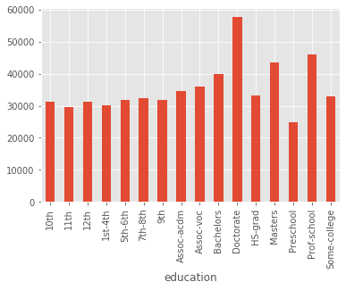

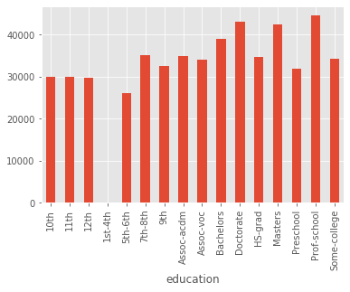

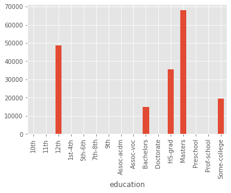

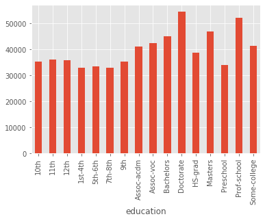

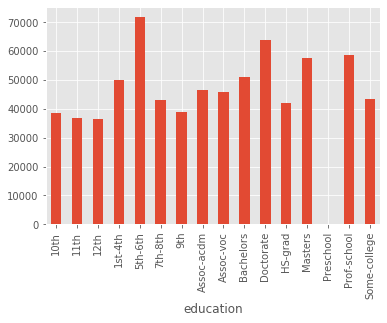

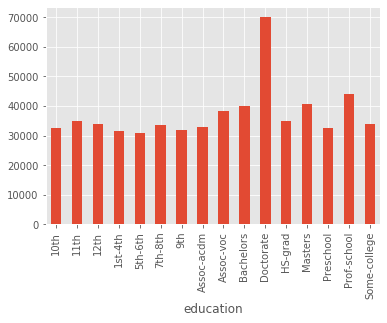

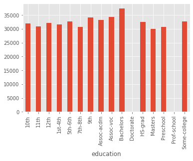

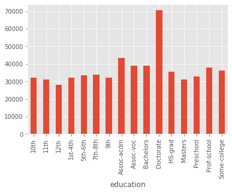

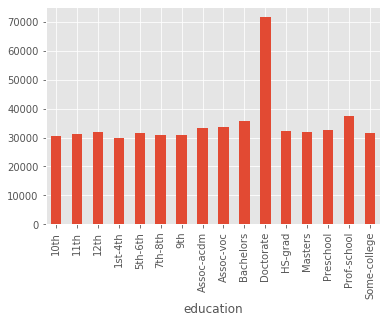

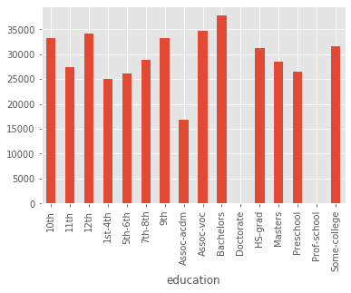

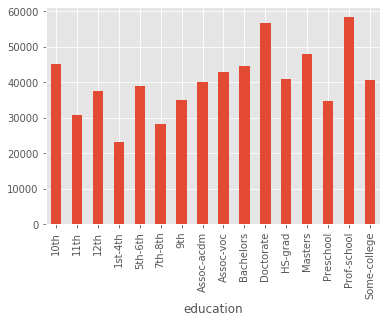

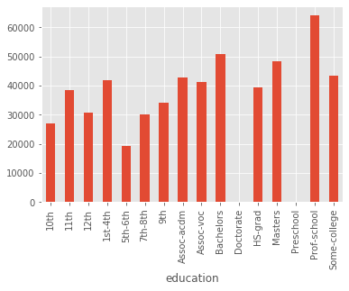

[3 more figures not shown]

```python
if crosstab_df is not crosstab_df.empty:
    for index, row in crosstab_df.iterrows():
        row.plot(kind = 'bar') # TODO
        plt.show()
```

**4.4. List 3 interesting facts that you can read out of these plots from subtask c.**

**Fact 1:** For occupation `armed-forces` it shows that for people who have education `12th` grade have higher salaries than people with `bachelors`, `some-college`. and `HS-grade` background.

**Fact 2:** For occupation `exec-managerial` it shows that for people with education `5th-6th` grade have the highest salaries compare to others.

**Fact 3:** For occupation `farming-fishing` the highest salaries is owned by people with 'Doctorate' education

## How long did it take you to solve the homework?

- Please answer as precisely as you can. It does not affect your points or grade in any way. It is okey, if it took 0.5 hours or 24 hours. The collected information will be used to improve future homeworks.

**Answer:**

**(please change X in the next cell into your estimate)**

10 hours

## How much the homework is difficult?

you can put only number between $0:10$ ($0:$ easy, $10:$ difficult)

**Answer: 6**